# T06: Multiclass Logistic Regression

## Let's first recall logistic regression for classification!

- Training set $\mathcal{D}=\left\{\mathbf{x}_i, y_i\right\}_{i=1}^N$, where $y_i \in\{0,1\}$.
- Probabilistic model $$ p(y \mid \mathbf{x}, \beta)=\operatorname{Ber}\left(y \mid \sigma\left(\beta^{\top} \mathbf{x}\right)\right) $$
  - $\sigma(z)$ is the sigmoid/logistic/logit function. $$ \sigma(z)=\frac{1}{1+\exp (-z)}=\frac{e^z}{e^z+1} $$
  - It maps $\mathbb{R}$ to $(0,1)$.

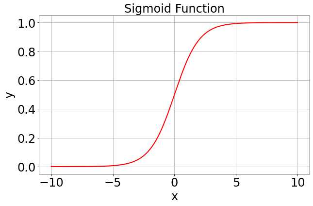

```python
import numpy as np
import pandas as pd
import matplotlib.pyplot as plt
import seaborn as sns
import statsmodels.api as sm

# Set random seed
np.random.seed(20221011)

# Generate data for the sigmoid function
x = np.sort(np.random.uniform(-10, 10, 1000))
y = 1 / (1 + np.exp(-x))

# Plot the sigmoid function
plt.figure(figsize=(10, 6))
plt.plot(x, y, color='red', linewidth=2)
plt.title('Sigmoid Function', fontsize=24)
plt.xlabel('x', fontsize=24)
plt.ylabel('y', fontsize=24)
plt.tick_params(axis='both', labelsize=24)
plt.grid()
plt.show()
```

## The maximum likelihood estimation

- Recall that, the likelihood is the joint probability function of joint density function of the data.
- Here, we have independent observations $\left(\mathbf{x}_i, y_i\right), i=1, \ldots, n$, each follow the (conditional) distribution $$ P\left(y_i=1 \mid \mathbf{x}_i\right)=\frac{1}{1+\exp \left(-\beta^T \mathbf{x}_i\right)}=1-P\left(y_i=0 \mid \mathbf{x}_i\right) $$
- So, the joint probability function is $$ \prod_{i=1, \ldots, n ; y_i=1} p\left(y_i=1 \mid \mathbf{x}_i\right) \prod_{i=1, \ldots, n ; y_i=0} p\left(y_i=0 \mid \mathbf{x}_i\right) $$ which can be conveniently written as $$ \prod_{i=1}^n \frac{\exp \left(y_i \beta^T \mathbf{x}_i\right)}{1+\exp \left(\beta^T \mathbf{x}_i\right)} $$
- The likelihood function is the same as the joint probability function, but viewed as a function of $\beta$. The log-likelihood function is $$ \ell=\sum_{i=1}^n\left[y_i \beta^T x_i-\log \left(1+\exp \left(\beta^T \mathbf{x}_i\right)\right)\right] $$
- Unlike linear regression, we can no longer write down the MLE in closed form. Instead, we need to use optimization algorithms to compute it.
  - Gradient descent
  - Newton’s method

## Generate data

```python
n = 500  # Sample size
p = 2    # Number of features

y = np.concatenate([np.zeros(n // 2), np.ones(n // 2)])
x_class1 = np.random.randn(n // 2, p) - 1
x_class2 = np.random.randn(n // 2, p) + 1
x = np.vstack((x_class1, x_class2))
data = pd.DataFrame(np.column_stack((y, x)), columns=["y", "x1", "x2"])
```

## Visualization

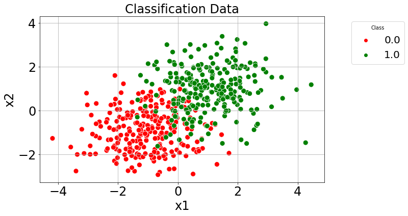

```python
# Convert y to categorical
data['y'] = data['y'].astype('category')

# Plot the classification data
plt.figure(figsize=(10, 6))
sns.scatterplot(data=data, x='x1', y='x2', hue='y', palette=['red', 'green'], s=100)
plt.title('Classification Data', fontsize=24)
plt.xlabel('x1', fontsize=24)
plt.ylabel('x2', fontsize=24)
plt.tick_params(axis='both', labelsize=24)
plt.legend(title='Class', fontsize=20, bbox_to_anchor = (1.3,1))
plt.grid()
plt.show()
```

## Implementation

```python
def mylogistic(y, x, method="Hessian", maxIter=500):
    n, p = x.shape
    y = y.reshape(-1,1)
    x = np.column_stack((np.ones(n), x))  # Add intercept
    XtX = np.dot(x.T, x)

    beta_old = np.zeros((p + 1, 1))
    prob = 1 / (1 + np.exp(-np.dot(x, beta_old)))

    for iter in range(maxIter):
        if method == "Hessian":
            W = prob * (1 - prob)
            temp = np.sqrt(W) * x
            XWX = np.dot(temp.T, temp)
            # Newton-Raphson update
            invH = np.linalg.inv(XWX)
            beta = beta_old + np.dot(invH, (np.dot(x.T, (y - prob))))
        else:
            # This is a method using the upper bound of Hessian
            # Because prob*(1-prob) <= 0.25
            # We replace prob*(1-prob) by 0.25
            z = 0.25 * np.dot(x, beta_old) + (y - prob)
            beta = np.linalg.solve(0.25 * XtX, np.dot(x.T, z))

        if np.max(np.abs(beta_old - beta)) / np.sqrt(np.sum(beta**2)) < 1e-6:
            break

        prob = 1 / (1 + np.exp(-np.dot(x, beta)))
        prob = np.clip(prob, 0.001, 0.999)

        beta_old = beta

    se = np.sqrt(np.diag(invH))
    return {'prob': prob, 'beta': beta, 'se': se, 'Iter': iter + 1}
```

```python
my_fit = mylogistic(y=(data.iloc[:,0].values).astype('int'), x=data[['x1', 'x2']].values, method="Hessian")
print("Estimated coefficients:", my_fit['beta'].flatten())
print("Iterations:", my_fit['Iter'])
print("Standard errors:", my_fit['se'])
```

```
Estimated coefficients: [-0.08002258  2.17128394  1.88221187]
Iterations: 10
Standard errors: [0.17984921 0.25011241 0.2247756 ]
```

## Built-in function

```python
glm_fit = sm.Logit(data['y'].cat.codes, sm.add_constant(data[['x1', 'x2']])).fit()
print(glm_fit.summary())
```

```
Optimization terminated successfully.
         Current function value: 0.204026
         Iterations 8
                           Logit Regression Results
==============================================================================
Dep. Variable:                      y   No. Observations:                  500
Model:                          Logit   Df Residuals:                      497
Method:                           MLE   Df Model:                            2
Date:                Sun, 13 Oct 2024   Pseudo R-squ.:                  0.7057
Time:                        21:00:02   Log-Likelihood:                -102.01
converged:                       True   LL-Null:                       -346.57
Covariance Type:            nonrobust   LLR p-value:                6.147e-107
==============================================================================
                 coef    std err          z      P>|z|      [0.025      0.975]
------------------------------------------------------------------------------
const         -0.0799      0.180     -0.445      0.656      -0.432       0.272
x1             2.1602      0.253      8.534      0.000       1.664       2.656
x2             1.8735      0.227      8.265      0.000       1.429       2.318
==============================================================================
```

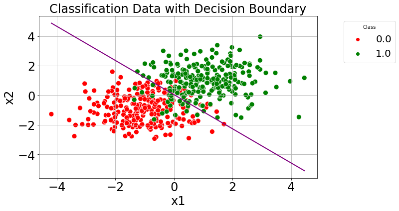

```python
plt.figure(figsize=(10, 6))
sns.scatterplot(data=data, x='x1', y='x2', hue='y', palette=['red', 'green'], s=100)
x_vals = np.linspace(data['x1'].min(), data['x1'].max(), 100)
y_vals = (-my_fit['beta'][0] - my_fit['beta'][1] * x_vals) / my_fit['beta'][2]
plt.plot(x_vals, y_vals, color='purple', linewidth=2)
plt.title('Classification Data with Decision Boundary', fontsize=24)
plt.xlabel('x1', fontsize=24)
plt.ylabel('x2', fontsize=24)
plt.tick_params(axis='both', labelsize=24)
plt.legend(title='Class', fontsize=20, bbox_to_anchor = (1.3,1))
plt.grid()
plt.show()
```

## Multiclass logistic regression

We now extend the two-class logistic regression approach to the setting of $K > 2$ classes. This extension is known as multiclass logistic regression or multinomial logistic regression.

To do this, we first select a single class to serve as the **baseline** (why?); without loss of generality, we select the $K$-th class for this role. Then $$ \operatorname{Pr}(Y=k \mid X=x)=\frac{e^{\beta_{k 0}+\beta_{k 1} x_1+\cdots+\beta_{k p} x_p}}{1+\sum_{l=1}^{K-1} e^{\beta_{l 0}+\beta_{l 1} x_1+\cdots+\beta_{l p} x_p}} $$ for $k=1, \ldots, K-1$, and $$ \operatorname{Pr}(Y=K \mid X=x)=\frac{1}{1+\sum_{l=1}^{K-1} e^{\beta_{l 0}+\beta_{l 1} x_1+\cdots+\beta_{l p} x_p}} . $$ It is not hard to show that for $k=1, \ldots, K-1$, $$ \log \left(\frac{\operatorname{Pr}(Y=k \mid X=x)}{\operatorname{Pr}(Y=K \mid X=x)}\right)=\beta_{k 0}+\beta_{k 1} x_1+\cdots+\beta_{k p} x_p $$ **Notice that the log odds between any pair of classes is linear in the features.**

## A toy example

### Generate data

```python
np.random.seed(20241013)
N = 1000  # Sample size
P = 2     # Number of features
K = 3     # Number of classes

# Generate features and coefficients
X = np.random.randn(N, P)  # Features, N * P
b = np.random.normal(3, 1, (P, K - 1))  # Coefficients, P * (K - 1)
```

```python
X
```

```
array([[ 1.81899607,  0.27176549],
       [-0.18405267, -0.57797361],
       [ 0.58327899, -0.32941768],
       ...,
       [-1.46430942, -1.35279912],
       [ 1.05492677,  0.41762662],
       [-0.10525239, -0.77753856]])
```

```python
b
```

```
array([[1.98920896, 3.84405831],
       [3.36578599, 2.57251504]])
```

```python
f = np.exp(X @ b)  # N * (K - 1)
prob = f / (1 + np.sum(f, axis=1, keepdims=True))  # Prob of Class 1 and 2, N * (K - 1)
prob = np.hstack((prob, 1 - np.sum(prob, axis=1, keepdims=True)))  # Prob of Class 1, 2, and 3, N * K
```

```python
f
```

```
array([[9.30435604e+01, 2.18954226e+03],
       [9.91169619e-02, 1.11430413e-01],
       [1.05286433e+00, 4.03387121e+00],
       ...,
       [5.72184114e-04, 1.10666777e-04],
       [3.32518904e+01, 1.68941211e+02],
       [5.92258382e-02, 9.02812076e-02]])
```

```python
prob
```

```
array([[4.07444990e-02, 9.58817593e-01, 4.37907781e-04],
       [8.18778050e-02, 9.20496092e-02, 8.26072586e-01],
       [1.72976848e-01, 6.62731473e-01, 1.64291679e-01],
       ...,
       [5.71793664e-04, 1.10591260e-04, 9.99317615e-01],
       [1.63646749e-01, 8.31431825e-01, 4.92142692e-03],
       [5.15228144e-02, 7.85390641e-02, 8.69938121e-01]])
```

```python
y = np.array([np.random.multinomial(1, p) for p in prob])
y
```

```
array([[0, 1, 0],
       [0, 0, 1],
       [0, 0, 1],
       ...,
       [0, 0, 1],
       [0, 1, 0],
       [0, 0, 1]])
```

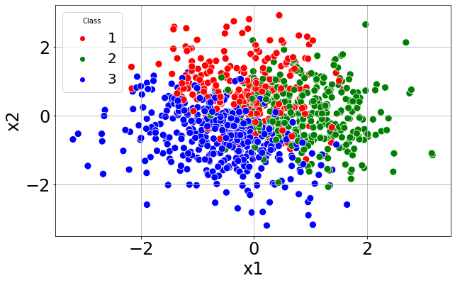

```python
# Visualization

# Encode to 1, 2, and 3
def class_encode(x):
    if x[0] == 1:
        return 1
    elif x[1] == 1:
        return 2
    else:
        return 3

y_encode = np.apply_along_axis(class_encode, 1, y)
y_encode = pd.Categorical(y_encode, categories=[1, 2, 3])

# Plotting
plt.figure(figsize=(10, 6))
sns.scatterplot(x=X[:, 0], y=X[:, 1], hue=y_encode, palette=['red', 'green', 'blue'], s=100)
plt.xlabel('x1', fontsize=24)
plt.ylabel('x2', fontsize=24)
plt.tick_params(axis='both', labelsize=24)
plt.legend(title='Class', fontsize=20)
plt.grid()
plt.show()
```

### Now let's fit multiclass logistic regression!

```python
def multLogReg(X, y, b_init=None, lambda_=0, tol=1e-4, inner_iter=100, outer_iter=100):
    # Data dimension
    N, P = X.shape
    K = y.shape[1]

    # Start solving

    X = np.hstack((np.ones((N, 1)), X)) # Add intercept
    XtX = X.T @ X
    Lambda = np.diag([0] + [lambda_] * P)

    # Initialize coefficients
    if b_init is None:
        b = np.zeros((P + 1, K - 1)) # Allow different initialization of beta0
    else:
        b = b_init

    b_old = b.copy()
    f = np.exp(X @ b_old)
    prob = f / (1 + np.sum(f, axis=1, keepdims=True))
    # prob = 1 / (1 + np.exp(-np.dot(x, beta_old)))

    for out in range(outer_iter):  # Outer iteration
        for l in range(K - 1):
            for inner in range(inner_iter):  # Inner iteration
                b_tmp = b[:, l].copy()  # Coefficients of l-th class
                z = 0.25 * X @ b_tmp + (y[:, l] - prob[:, l])  # Use last class as baseline
                b[:, l] = np.linalg.solve(0.25 * XtX + Lambda, X.T @ z)

                if np.max(np.abs(b_tmp - b[:, l])) / np.linalg.norm(b[:, l]) < tol:
                    break

                f[:, l] = np.exp(X @ b[:, l])
                prob = f / (1 + np.sum(f, axis=1, keepdims=True))

                # Safe guard
                prob = np.clip(prob, 0.001, 0.999)

        if np.max(np.abs(b_old - b)) / np.linalg.norm(b) < tol:
            break

        b_old = b.copy()

    return b
```

```python
b_hat = multLogReg(X, y)
b_hat
```

```
array([[-0.03407293,  0.01851146],
       [ 2.07595444,  3.81413738],
       [ 3.42020967,  2.52251442]])
```

Remember that for $k=1, \ldots, K-1$, $$ \log \left(\frac{\operatorname{Pr}(Y=k \mid X=x)}{\operatorname{Pr}(Y=K \mid X=x)}\right)=\beta_{k 0}+\beta_{k 1} x_1+\cdots+\beta_{k p} x_p. $$ Let $\frac{\operatorname{Pr}(Y=k \mid X=x)}{\operatorname{Pr}(Y=K \mid X=x)} = 1$, we can get $$ \beta_{k 0}+\beta_{k 1} x_1+\cdots+\beta_{k p} x_p = 0. $$ In this case $p = 2$, so $$ \beta_{k 0}+\beta_{k 1} x_1+\beta_{k 2} x_2 = 0,\\ x_2 = - \frac{\beta_{k 0}}{\beta_{k 2}} - \frac{\beta_{k 1}}{\beta_{k 2}} x_1. $$

Suppose we do not know which is the **baseline** class and assume it was chosen at random. (Actually we know it.)

Let's first visualize the known classification line.

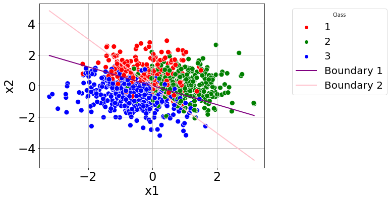

```python
# Plotting with decision boundaries
plt.figure(figsize=(8, 6))
sns.scatterplot(x=X[:, 0], y=X[:, 1], hue=y_encode, palette=['red', 'green', 'blue'], s=100)
x_vals = np.linspace(X[:, 0].min(), X[:, 0].max(), 100)

# Decision boundaries
for i in range(K - 1):
    y_vals = (-b_hat[0, i] - b_hat[1, i] * x_vals) / b_hat[2, i]
    plt.plot(x_vals, y_vals, linewidth=2, label=f'Boundary {i + 1}', color=['purple', 'pink'][i])

plt.xlabel('x1', fontsize=24)
plt.ylabel('x2', fontsize=24)
plt.tick_params(axis='both', labelsize=24)
plt.legend(title='Class', fontsize=20, bbox_to_anchor = (1.1,1))
plt.grid()
plt.show()
```

We can see that the purple line is between class 1 and 3, and the pink line is between class 2 and 3. So the **baseline** here is class 3, and $$ \log \left(\frac{\operatorname{Pr}(Y=1 \mid X=x)}{\operatorname{Pr}(Y=3 \mid X=x)}\right) = -0.03 + 2.08 x_1 + 3.42 x_2, \\ \log \left(\frac{\operatorname{Pr}(Y=2 \mid X=x)}{\operatorname{Pr}(Y=3 \mid X=x)}\right) = 0.02 + 3.81 x_1 + 2.52 x_2. $$ Therefore, $$ \log \left(\frac{\operatorname{Pr}(Y=1 \mid X=x)}{\operatorname{Pr}(Y=2 \mid X=x)}\right) = (-0.03-0.02) + (2.08 - 3.81) x_1 + (3.42 - 2.52) x_2. $$

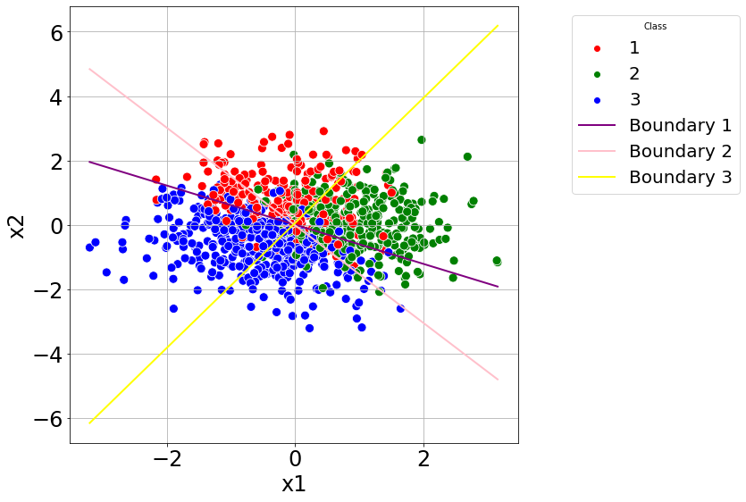

```python
# # Full figure with additional decision boundary
plt.figure(figsize=(9, 9))
sns.scatterplot(x=X[:, 0], y=X[:, 1], hue=y_encode, palette=['red', 'green', 'blue'], s=100)
x_vals = np.linspace(X[:, 0].min(), X[:, 0].max(), 100)

# Decision boundaries
for i in range(K - 1):
    y_vals = (-b_hat[0, i] - b_hat[1, i] * x_vals) / b_hat[2, i]
    plt.plot(x_vals, y_vals, linewidth=2, label=f'Boundary {i + 1}', color=['purple', 'pink'][i])

# Additional boundary between class 1 and class 2
y_vals = (-(b_hat[0, 0] - b_hat[0, 1]) - (b_hat[1, 0] - b_hat[1, 1]) * x_vals) / (b_hat[2, 0] - b_hat[2, 1])
plt.plot(x_vals, y_vals, linewidth=2, color='yellow', label='Boundary 3')

plt.xlabel('x1', fontsize=24)
plt.ylabel('x2', fontsize=24)
plt.tick_params(axis='both', labelsize=24)
plt.legend(title='Class', fontsize=20, bbox_to_anchor = (1.1,1))
plt.grid()
plt.show()
```